# DATASCI 350 - Data Science Computing

Lecture 14 - Introduction to Cloud Computing

Danilo Freire

danilo.freire@emory.edu

Department of Data and Decision Sciences  
Emory University

# Hello, everyone! 👋

# Brief recap 📚

## Local LLMs and AI agents

- We saw many cool things last class!
- There are many pros of using local LLMs:
  - Privacy, security, control, and customisation
- [Ollama](https://ollama.com) is a great software for that!
  - It lets you download and run hundreds of LLMs locally
  - It’s free and open source, and easy to customise with `Modelfiles`
- We also saw how to use [LM Studio](https://lmstudio.ai) and [Hugging Face](https://huggingface.co)
  - You have more than [two million models](https://huggingface.co/models) to choose from!

[figure not shown]

https://ollama.com

## Local LLMs and AI agents

- We learnt about LLM APIs and how to use them via [OpenRouter](https://openrouter.ai)
  - There are many free models available, just search for “free” in the search bar
- We also saw how to use [Roo Code](https://github.com/RooVetGit/Roo-Code) and integrate APIs in VS Code
  - You can use any API with a friendly interface
  - You can fully automate your workflow with agents
- Finally, we learnt how to use [Web-UI](https://github.com/browser-use/web-ui)
- Web-UI makes websites accessible for AI agents, and it can perform pretty much any task on the internet
- Have a look at its parent project too: [Browser Use](https://github.com/browser-use/browser-use)
  - You can use it in Python and integrate it in your scripts!

[figure not shown]

https://github.com/browser-use/web-ui

## Browser use

### Add grocery items to cart, and checkout

[video not shown]

If the video doesn’t play, please click [here](https://www.youtube.com/watch?v=L2Ya9PYNns8)

# Cloud computing ☁️

## What is cloud computing?

- Cloud computing is the on-demand delivery of computing resources through a cloud services platform via the internet with pay-as-you-go pricing
- They’ve become more popular due to scalability, flexibility, and cost-efficiency
- There are four main types of cloud computing services: IaaS, PaaS, SaaS, and FaaS
- The most popular platforms are Amazon Web Services (AWS), Microsoft Azure, and Google Cloud Platform (GCP), the “Big Three”
- They are so widely used that Amazon’s AWS is the most profitable division of the company
  - Although it is only 15% of their total sales, it accounts for more than 50% of their profits (~$28 billion)

[figure not shown]

Source: [GeekWire (2025)](https://www.geekwire.com/2025/amazons-quarterly-profits-soar-to-a-record-20-billion-but-cloud-growth-comes-up-short/)

# Why should we care about cloud computing? 🤔

## Imagine you are opening a business…

### Traditional approach

1. Estimate supply and demand
2. Estimate infrastructural needs
3. Purchase and deploy infrastructure
4. Install and test your system
5. Offer your services to clients
- Infrastructure is very expensive:
  - Hardware costs (Dell is charging [~15k for its least expensive server](https://www.dell.com/en-us/shop/cty/pdp/spd/poweredge-r570/na_promo_per570_2))
  - Real estate costs
  - Cooling system, power bill
  - A few systems engineers
  - Redundancy for high reliability
- It takes time to deploy the infrastructure
- What if the estimations were wrong?

## Imagine you are opening a business…

### Cloud approach

1. Choose one or more cloud services providers
2. Deploy your systems on the cloud
3. Offer your services to clients
4. Pay for what you use

| **Traditional process** | **With Cloud Computing** |
| --- | --- |
| ❌ High investment risk | ✅ Reduced risk |
| ❌ Long time-to-market | ✅ Shorter time-to-market |
| ✅ Manages own data | ❌ Trust the vendor? |
| ✅ Completely in control | ❌ Dependent on a specific vendor? |

## Case study: Animoto

- [Animoto](https://animoto.com/): Lets users create videos from their own photos/music
- Built using [Amazon EC2](https://aws.amazon.com/ec2/) (Elastic Compute Cloud) + [S3](https://aws.amazon.com/s3/) (Simple Storage Service) + [SQS](https://aws.amazon.com/sqs/) (Simple Queue Service)
- Released a Facebook app in mid-April 2008
- More than 750,000 people signed up within 3 days
- EC2 usage went from 50 machines to 3,500 (x70 scalability!)
- No way they could have done this with traditional infrastructure!

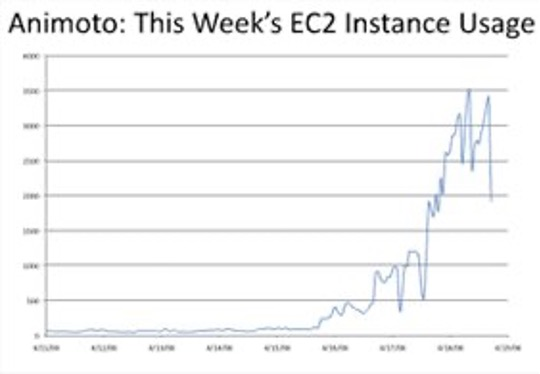

Source: [Jeff Bezos’ talk at Stanford in 2008](https://youtu.be/6nKfFHuouzA?si=M5LCwMxMUC5Ay3oY)

## Case study: The Washington Post

- Hillary Clinton’s official White House schedule released to the public
- 17,481 pages of non-searchable, low-quality PDF
- Very interesting to journalists, but would have required hundreds of man-hours to evaluate
- Peter Harkins, Senior Engineer at The Washington Post: “Can we make that data available more quickly, ideally within the same news cycle?”
- Tested various Optical Character Recognition (OCR) programs; estimated required speed
- Launched 200 EC2 instances; project was completed within nine hours using 1,407 hours of VM time ($144.62)
- Results available on the web only 26 hours after the release

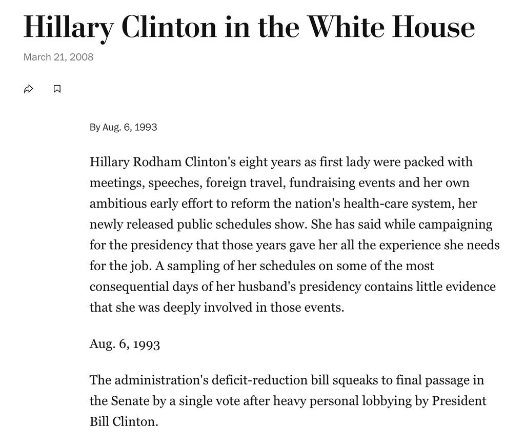

Source: [The Washington Post](https://www.washingtonpost.com/archive/politics/2008/03/21/hillary-clinton-in-the-white-house/200a2e1f-efb4-469a-b5dd-05e87675b598/)

# Cloud computing services ☁️

## Cloud computing services

- SaaS (Software as a Service):
  - Software is hosted on a cloud and accessed via the internet as a complete application
  - You don’t have to worry about updates, security, or maintenance
  - You often pay a subscription fee (monthly or yearly)
  - Examples: [Gmail](https://gmail.com), [Office 365](https://www.office.com), [Salesforce](https://www.salesforce.com), [GitHub Copilot](https://github.com/features/copilot)
- PaaS (Platform as a Service):
  - Provides a platform allowing customers to develop, run, and manage applications without the complexity of building and maintaining the infrastructure
  - Usually, the platform offers a series of APIs
  - You pay for the platform and the resources you use (e.g., storage, bandwidth)
  - Examples: [Google App Engine](https://cloud.google.com/appengine), [AWS Elastic Beanstalk](https://aws.amazon.com/elasticbeanstalk), [Heroku](https://www.heroku.com), [GitHub Actions/Codespaces/Pages](https://github.com/features/actions)

## Cloud computing services

### SaaS

[figure not shown]

## Cloud computing services

### PaaS

[figure not shown]

## Cloud computing services

- FaaS (Function as a Service):
  - Allows you to run code without provisioning or managing servers
  - You pay for the time your code/function runs
  - Examples: [AWS Lambda](https://aws.amazon.com/lambda), [Google Cloud Functions](https://cloud.google.com/functions), [Azure Functions](https://azure.microsoft.com/en-us/services/functions)
- IaaS (Infrastructure as a Service):
  - Provides virtualised computing resources over the internet
  - You can rent virtual machines, storage, and networking
  - You pay for the resources you use
  - Examples: [AWS EC2](https://aws.amazon.com/ec2), [Google Compute Engine](https://cloud.google.com/compute), [Azure Virtual Machines](https://azure.microsoft.com/en-us/services/virtual-machines)

## Cloud computing services

### FaaS

[figure not shown]

## Cloud computing services

### IaaS

[figure not shown]

## Comparison of cloud services

| On-premise | IaaS | PaaS | SaaS |
| --- | --- | --- | --- |
| Application | Application | Application | Application |
| Middleware | Middleware | Middleware | Middleware |
| OS | OS | OS | OS |
| Virtualisation | Virtualisation | Virtualisation | Virtualisation |
| Servers | Servers | Servers | Servers |
| Networking | Networking | Networking | Networking |

User manages  
Provider manages

## What is middleware?

- Middleware is software that connects two separate applications
- This is software we rarely see, but which is essential for the functioning of the internet
- For instance, software that handles authentication, authorisation, and encryption, drivers that connect to databases, etc
- [Amazon SQS](https://aws.amazon.com/sqs), [Apache Kafka](https://kafka.apache.org), and [RabbitMQ](https://www.rabbitmq.com) are examples of middleware

[figure not shown]

## What is virtualisation?

- Suppose Alice has a machine with 4 CPUs and 8 GB of memory, and three customers:
  - Bob wants a machine with 1 CPU and 3 GB of memory
  - Charlie wants 2 CPUs and 1 GB of memory
  - Daniel wants 1 CPU and 4 GB of memory
- What should Alice do?
- Alice can sell each customer a virtual machine (VM) with the requested resources
- From each customer’s perspective, it appears as if they had a physical machine all by themselves (isolation)

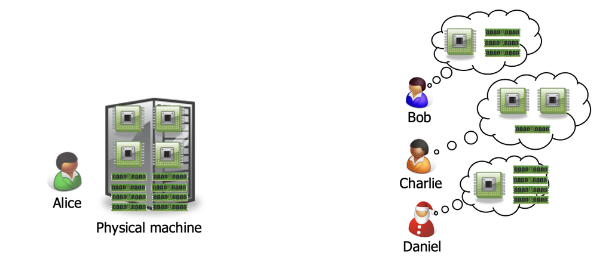

More about [virtualisation](https://www.redhat.com/en/topics/virtualization/what-is-virtualization)

# Amazon Web Services (AWS) 🛠️

## Amazon Web Services (AWS)

- AWS is a collection of cloud-based services
- It’s a very large platform
- Let me say it again: a VERY LARGE ONE 😂
- They offer a wide range of services:
  - Compute, storage, databases, analytics, machine learning, AI, IoT, security, and more
- Many companies use AWS, including Netflix, Airbnb, and NASA
- The most widely used services are [EC2](https://aws.amazon.com/ec2), [S3](https://aws.amazon.com/s3), and [RDS](https://aws.amazon.com/rds), for computing, storage, and databases, respectively
- Let’s look at them in more detail

[figure not shown]

https://aws.amazon.com

## Amazon EC2 - Elastic Compute Cloud

- Amazon EC2 is a web service that provides resizable compute capacity
- It’s designed to make web-scale cloud computing easier
- You can launch instances with a many operating systems (mainly Linux)
- Which means that you can use Bash and run any software you want from the command line
- You can also use a GUI, but it is not necessary
- You can use EC2 to host a website, run a database, run a machine learning model, etc
- However, please be mindful of the costs!
- You pay for the instances you use, and the costs can add up quickly
- Per-second (or per-hour) billing
- Data transfer is not included!
- Persistent storage is not included!
- Scaling is not included!

[figure not shown]

## EC2 auto scaling

- Scaling is the ability to increase or decrease the compute capacity of your application
- You can do it manually or automatically
- Useful when you have fluctuating workloads, such as a website that gets more traffic during the day, or a machine learning model that gets more requests at certain times
- You can also set up load balancers to distribute traffic across multiple instances

[figure not shown]

Source: [AWS](https://aws.amazon.com/autoscaling)

## ELB - Elastic Load Balancer

- ELB is a service that distributes incoming application traffic across multiple targets
- It handles the varying load of your application traffic in a single availability zone or across multiple availability zones
- ELB is a key component of auto scaling
- As with EC2, you pay for the data transfer and the number of requests
- And it can be quite expensive too
- It can detect unhealthy instances and reroute traffic to healthy instances, so your application is always available

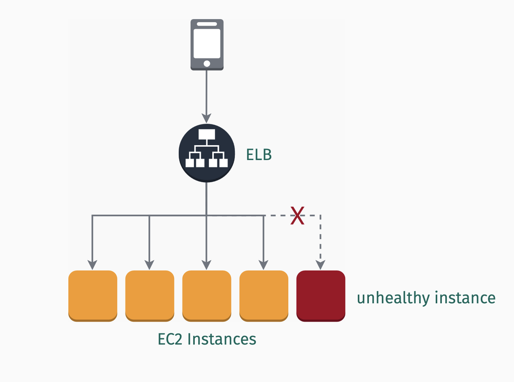

## Cloud storage

### Amazon S3 - Simple Storage Service

- Amazon has three main storage services: [S3](https://aws.amazon.com/s3) (Simple Storage Service), [EBS](https://aws.amazon.com/ebs) (Elastic Block Store), and [EFS](https://aws.amazon.com/efs) (Elastic File System)
- S3 is a web service that provides scalable object storage for data backup, archival, and analytics
- You can store data in buckets, which are like folders
- Data are distributed across a minimum of three availability zones
  - 99.999999999% durability (eleven nines!)
- You can set up lifecycle policies to automatically move data to cheaper storage classes
  - Standard, Intelligent-Tiering, Glacier, Glacier Deep Archive
- You can also set up versioning to keep multiple versions of an object (works like `git`)

[figure not shown]

https://aws.amazon.com/s3/

## Cloud storage

### Amazon EBS - Elastic Block Store

- EBS is a web service that provides block storage volumes for use with EC2 instances
- The difference between S3 and EBS is that EBS is block storage, while S3 is object storage
  - Block storage is like a hard drive, while object storage is like a file system
- Why would you use it? Mainly for SQL files
  - Low-latency, high-performance storage for frequent access
- You can attach EBS volumes to your EC2 instances
- You can also take snapshots of your volumes for backup (like `git` again!)
- Up to 16 TB per volume

[figure not shown]

https://aws.amazon.com/ebs/

## Amazon EFS - Elastic File System

- EFS is a web service that provides scalable file storage for use with EC2 instances
- EFS is mainly used for shared file storage
  - Multiple EC2 instances can access the same file system
  - Useful for big data and analytics
  - Also for content management and web serving
- You can create file systems and mount them to your EC2 instances
- As with S3 and EBS, you pay for the storage you use

[figure not shown]

https://aws.amazon.com/efs/

## Database services

### Amazon RDS - Relational Database Service

- [Amazon RDS](https://aws.amazon.com/rds/) is a web service that makes it easy to set up and operate a relational database
- You can choose from six popular database engines:
  - Amazon Aurora, PostgreSQL, MySQL, MariaDB, Oracle, and SQL Server
- It’s a managed service, so you don’t have to worry about backups, patches, or updates
- It works well with another AWS service called [Athena](https://aws.amazon.com/athena/), which allows you to query data in S3 using SQL
- You can also use [Redshift](https://aws.amazon.com/redshift/) for data warehousing and business analytics, and [DynamoDB](https://aws.amazon.com/dynamodb/) for NoSQL databases

[figure not shown]

https://aws.amazon.com/rds/

## Amazon SageMaker

- Finally, let’s talk about [Amazon SageMaker](https://aws.amazon.com/sagemaker/)
- SageMaker is a fully managed service that allows you to build, train, and deploy machine learning models at scale
- It has several pre-configured models, such as TensorFlow, PyTorch, and Scikit-learn
- You can also bring your own models too, and use Jupyter notebooks to train them
- Lots of other models available in the [AWS Marketplace](https://aws.amazon.com/marketplace), and you can also use [SageMaker Studio](https://aws.amazon.com/sagemaker/ai/studio/) to manage your projects
- Some application services
  - [Comprehend (for NLP)](https://aws.amazon.com/comprehend/)
  - [Rekognition (Visual Analysis)](https://aws.amazon.com/rekognition/)
  - [Translate](https://aws.amazon.com/translate/)
  - [Polly (text-to-speech)](https://aws.amazon.com/polly/)

[figure not shown]

https://aws.amazon.com/sagemaker/

# Creating and managing an AWS account 🛠️

## Creating an AWS account

### You can do this later if you want

- To create an AWS account, go to https://aws.amazon.com/free/ and click on Create a Free Account
- Then, add your email and choose an account name (any name will do)
- Enter your account information, and then choose *Verify email address*
- You will receive an email with a verification link, add the code from the email
- Follow the instructions to set up your account
- Enter your billing information, yes, you need to 😒
- Enter the code displayed in the CAPTCHA, and then submit
- Choose Complete sign up
- And you’re done 🎉

[figure not shown]

https://aws.amazon.com/free/

## Managing an AWS account

- The first thing you should do is to use a billing alarm
  - You can set up a billing alarm to notify you when your bill exceeds a certain amount
  - This is very important, as costs can add up quickly
- Go to https://console.aws.amazon.com/costmanagement/
- In the navigation pane, choose Billing Preferences (scroll down to the bottom)
- By Alert preferences choose Edit
- Choose Receive AWS Free Tier Alerts
- Choose Save preferences
- Then go to https://us-east-1.console.aws.amazon.com/billing/home#/budgets/overview
- Choose Create budget, choose a Zero spend budget template, add your email, then click Create budget

## Managing an AWS account

[figure not shown]

# Amazon Transcribe 🎤

## Audio transcription at scale

- Imagine that you have a task similar to that of the Washington Post journalists
- You found a series of audio files that you need to transcribe, and you have to do it quickly
- So let’s create an S3 bucket (folder), upload an audio file, and transcribe it
- The file we will use is available here: [transcribe-sample.mp3](https://d1.awsstatic.com/tmt/create-audio-transcript-transcribe/transcribe-sample.5fc2109bb28268d10fbc677e64b7e59256783d3c.mp3)
- Select [AWS Management Console](https://us-east-1.console.aws.amazon.com/console/home?region=us-east-1) to open the console, then search for `S3` in the search bar
- Click on Create bucket, give it a name, accept the permissions, and click Create bucket

[figure not shown]

## Audio transcription at scale

[figure not shown]

[figure not shown]

## S3 bucket

[figure not shown]

Then click on the bucket and upload the file

## Create transcription job

- Now let’s go to [Amazon Transcribe](https://us-east-1.console.aws.amazon.com/transcribe/home?region=us-east-1)
- Just search for `Transcribe` in the search bar
- Click on Transcription jobs (left sidebar), then click on Create job
- Give it a name, select the language, and choose the S3 bucket where the file is located
- Click Create

[figure not shown]

## Transcription job

[figure not shown]

[figure not shown]

## Transcription job

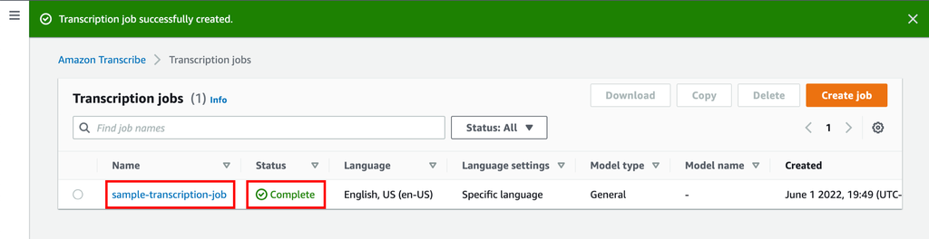

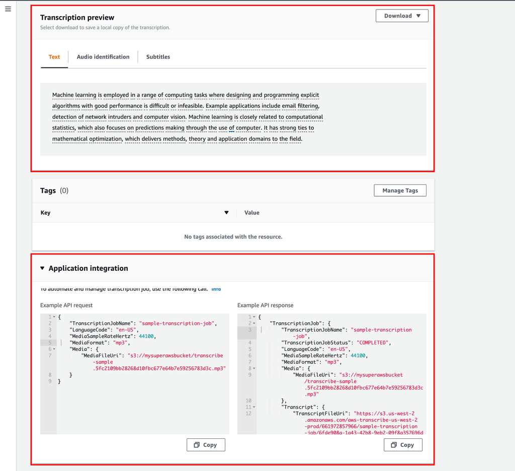

# Conclusion 🎉

## What we learned today

- Why cloud computing is important and how it can help your business
- The Big Three cloud computing platforms: AWS, Azure, and GCP
- The main types of cloud computing services: IaaS, PaaS, SaaS, FaaS
- The most popular AWS services: EC2, S3, RDS, SageMaker
- How to create an AWS account and set up a billing alarm
- How to create an S3 bucket, upload an audio file, and transcribe it with Amazon Transcribe
- And that’s just the beginning!
- In the next sessions, we will learn more about AWS services, and how to use them to build and deploy applications
- Remember to close your EC2 instances and S3 buckets when you’re done!

[figure not shown]

# And that’s a wrap! 🎬

# Thank you very much! See you next time! 😊🙏🏽